# Practical Machine Learning Assignment

Kumar Suraj

30 May 2017

## R Markdown

One thing that people regularly do is quantify how much of a particular activity they do, but they rarely quantify how well they do it. In this project, the goal is to use data from accelerometers on the belt, forearm, arm, and dumbell of 6 participants.

The goal of the project is to predict the manner in which people did the exercise. This is the “classe” variable in the training set.

```r
#import libraries
library(caret)
library(rpart)
library(randomForest)
library(rattle)
#loading the dataset
data = read.csv('C:/Users/Kumar Suraj/Desktop/Acads/Others/pml-training.csv', na.strings = c("NA", ""))

#dividing into training and validationidation data
set.seed(112)
intrain = createDataPartition(data$classe, p = 0.75, list = F)
training = data[intrain, ]
val = data[-intrain, ]
```

```r
dim(val)
```

```
## [1] 4904  160
```

```r
dim(training)
```

```
## [1] 14718   160
```

## Data Preprocessing

Data was checked for near zero variance, and columns with near zero variance were removed from the training dataset.

```r
nzvCols = nearZeroVar(training, saveMetrics = F)
newtrain = training[,-nzvCols]
```

```r
dim(newtrain)
```

```
## [1] 14718   122
```

```r
# data preprocessing

manyNA = sapply(newtrain, function(x){sum(is.na(x))/nrow(data)})>0.01
sum(manyNA)
```

```
## [1] 63
```

```r
newtrain2 = newtrain[,manyNA == FALSE]
sum(sapply(newtrain2, function(x){sum(is.na(x))/nrow(data)})>0.01)
```

```
## [1] 0
```

```r
dim(newtrain2)
```

```
## [1] 14718    59
```

```r
newtrain3 = newtrain2[,-1]
newtrain3 = newtrain3[, -c(newtrain3$cvtd_timestamp)]
newtrain3$classe = factor(newtrain3$classe)
```

## Decision Tree

Initially, decision tree was fitted, and the model was checked for accuracy and kappa values on the validation set.

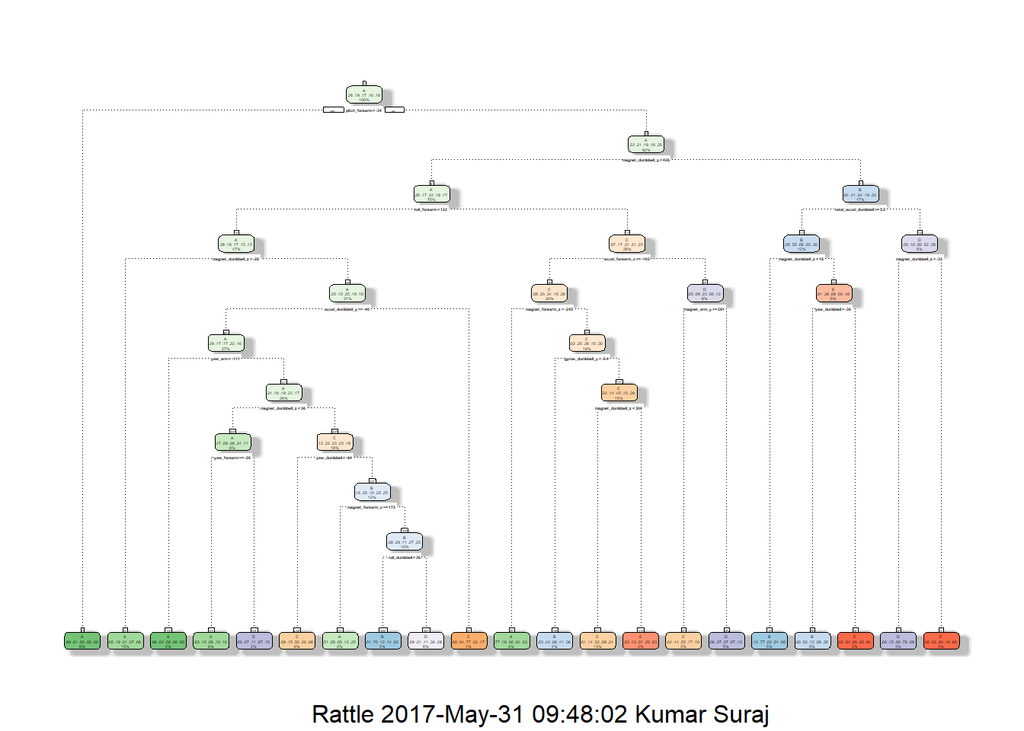

```r
#dtree
set.seed(12345)
treemodel = rpart(classe ~ ., data = newtrain3)
fancyRpartPlot(treemodel)
```

```r
treepred = predict(treemodel, newdata = val, type = 'class')
levels(treepred)
```

```
## [1] "A" "B" "C" "D" "E"
```

```r
cfmat = confusionMatrix(treepred, val$classe)
cfmat
```

```
## Confusion Matrix and Statistics
##
##           Reference
## Prediction    A    B    C    D    E
##          A 1252  207   32  112  121
##          B   40  420   66   41  157
##          C   39  138  666  137  203
##          D   61  160   90  462  191
##          E    3   24    1   52  229
##
## Overall Statistics
##
##                Accuracy : 0.6177
##                  95% CI : (0.6039, 0.6313)
##     No Information Rate : 0.2845
##     P-Value [Acc > NIR] : < 2.2e-16
##
##                   Kappa : 0.5133
##  Mcnemar's Test P-Value : < 2.2e-16
##
## Statistics by Class:
##
##                      Class: A Class: B Class: C Class: D Class: E
## Sensitivity            0.8975  0.44257   0.7789  0.57463  0.25416
## Specificity            0.8655  0.92314   0.8723  0.87756  0.98001
## Pos Pred Value         0.7262  0.58011   0.5630  0.47925  0.74110
## Neg Pred Value         0.9550  0.87344   0.9492  0.91320  0.85375
## Prevalence             0.2845  0.19352   0.1743  0.16395  0.18373
## Detection Rate         0.2553  0.08564   0.1358  0.09421  0.04670
## Detection Prevalence   0.3515  0.14763   0.2412  0.19657  0.06301
## Balanced Accuracy      0.8815  0.68285   0.8256  0.72609  0.61709
```

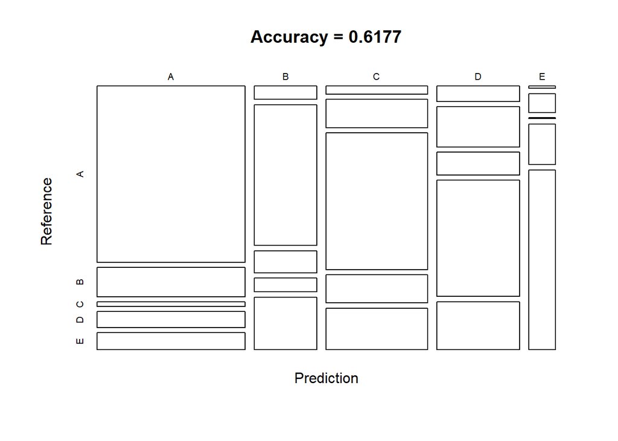

```r
plot(cfmat$table, col = cfmat$byClass,
     main = paste("Accuracy =",
                  round(cfmat$overall['Accuracy'], 4)))
```

```r
#rf
set.seed(1234)
rfmodel = randomForest(classe~., newtrain3 )
rfpred = predict(rfmodel, newdata = val, method = 'class')
cfmat = confusionMatrix(rfpred, val$classe)
cfmat
```

```
## Confusion Matrix and Statistics
##
##           Reference
## Prediction    A    B    C    D    E
##          A 1390   13    0    2    0
##          B    4  933   10    0    3
##          C    1    2  845   24    3
##          D    0    1    0  771    6
##          E    0    0    0    7  889
##
## Overall Statistics
##
##                Accuracy : 0.9845
##                  95% CI : (0.9806, 0.9878)
##     No Information Rate : 0.2845
##     P-Value [Acc > NIR] : < 2.2e-16
##
##                   Kappa : 0.9804
##  Mcnemar's Test P-Value : NA
##
## Statistics by Class:
##
##                      Class: A Class: B Class: C Class: D Class: E
## Sensitivity            0.9964   0.9831   0.9883   0.9590   0.9867
## Specificity            0.9957   0.9957   0.9926   0.9983   0.9983
## Pos Pred Value         0.9893   0.9821   0.9657   0.9910   0.9922
## Neg Pred Value         0.9986   0.9960   0.9975   0.9920   0.9970
## Prevalence             0.2845   0.1935   0.1743   0.1639   0.1837
## Detection Rate         0.2834   0.1903   0.1723   0.1572   0.1813
## Detection Prevalence   0.2865   0.1937   0.1784   0.1586   0.1827
## Balanced Accuracy      0.9961   0.9894   0.9904   0.9786   0.9925
```

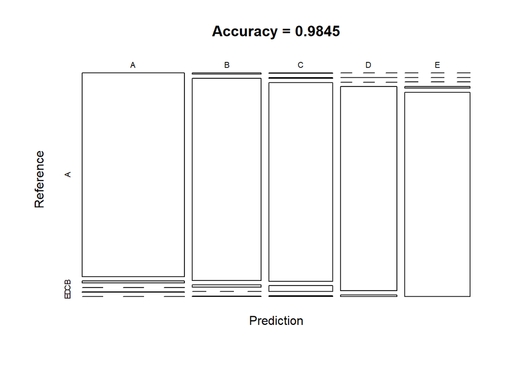

```r
plot(cfmat$table, col = cfmat$byClass,
     main = paste("Accuracy =",
                  round(cfmat$overall['Accuracy'], 4)))
```

## Generalized Boosted Model

```r
#gbm
set.seed(1123)
gbmmodel = train(classe~., data = newtrain3, method = "gbm", verbose = F,  trControl= trainControl(method = "repeatedcv", number = 5, repeats = 1))
gbmpred = predict(gbmmodel, newdata = val)
cfmat = confusionMatrix(gbmpred, val$classe)
cfmat
```

```
## Confusion Matrix and Statistics
##
##           Reference
## Prediction    A    B    C    D    E
##          A 1354   83   12   15    3
##          B   15  770   50    9   46
##          C   10   50  769   65   35
##          D   12   15    8  685   57
##          E    4   31   16   30  760
##
## Overall Statistics
##
##                Accuracy : 0.8846
##                  95% CI : (0.8753, 0.8934)
##     No Information Rate : 0.2845
##     P-Value [Acc > NIR] : < 2.2e-16
##
##                   Kappa : 0.8538
##  Mcnemar's Test P-Value : < 2.2e-16
##
## Statistics by Class:
##
##                      Class: A Class: B Class: C Class: D Class: E
## Sensitivity            0.9706   0.8114   0.8994   0.8520   0.8435
## Specificity            0.9678   0.9697   0.9605   0.9776   0.9798
## Pos Pred Value         0.9230   0.8652   0.8278   0.8816   0.9037
## Neg Pred Value         0.9881   0.9554   0.9784   0.9712   0.9653
## Prevalence             0.2845   0.1935   0.1743   0.1639   0.1837
## Detection Rate         0.2761   0.1570   0.1568   0.1397   0.1550
## Detection Prevalence   0.2991   0.1815   0.1894   0.1584   0.1715
## Balanced Accuracy      0.9692   0.8905   0.9299   0.9148   0.9116
```

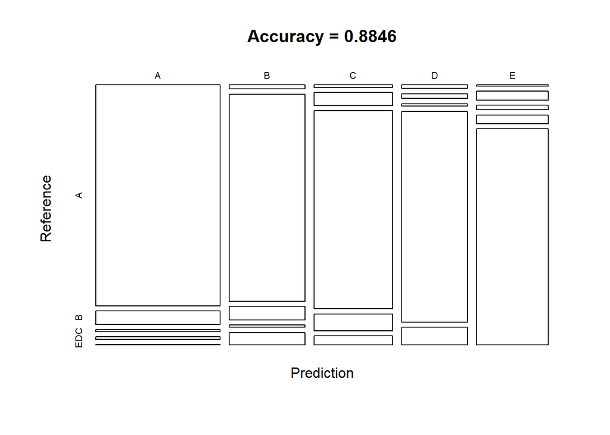

```r
plot(cfmat$table, col = cfmat$byClass,
     main = paste("Accuracy =",
                  round(cfmat$overall['Accuracy'], 4)))
```

## Prediction on Test set

Since randm forest model performed best on the validation set, it was chosen for predicting on the test set.

```r
#Prediction on the test set
testing = read.csv('C:/Users/Kumar Suraj/Desktop/Acads/Others/pml-testing.csv', na.strings = c("NA", ""))
newtesting = testing[,names(testing)%in%names(newtrain3)]
prediction = predict(rfmodel, newdata =  newtesting, method = 'class' )
prediction
```

```
##  1  2  3  4  5  6  7  8  9 10 11 12 13 14 15 16 17 18 19 20
##  B  A  B  A  A  E  D  B  A  A  B  C  B  A  E  E  A  B  B  B
## Levels: A B C D E
```